# Assignement

2023-04-25

# Qusetion 1

## Load dataset

```
##  Time-Series [1:64] from 1996 to 2012: 89.1 89.5 89.9 90.1 89.2 ...
```

The database presents the Quarterly Index of Retail Trade in the Eurozone (17 countries), over the period 1996-2012. It is a time series of 64 observations.

## Plot a data

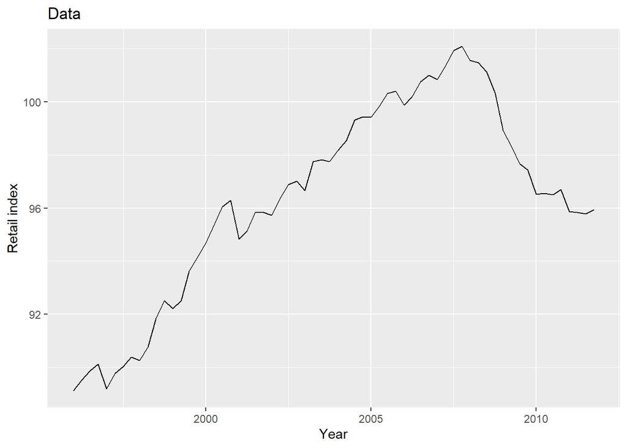

Since the time series has a non-stationary variance, it would be interesting to perform a logarithmic or Box-Cox transformation on the data. As for the stationarity, the graph suggests that the series is not stationary. We will have more precision by performing an augmented Dickey-Fuller test.

## Stationarity check

```
##
##  Augmented Dickey-Fuller Test
##
## data:  euretail
## Dickey-Fuller = -0.17892, Lag order = 3, p-value = 0.99
## alternative hypothesis: stationary
```

With an alpha of 0.05 and p-value of 0.99, we fail to reject the null ans stat that the series is not stationary.

## Forecasting

```
## Series: euretail
## ARIMA(0,1,3)(0,1,1)[4]
##
## Coefficients:
##          ma1     ma2     ma3     sma1
##       0.2630  0.3694  0.4200  -0.6636
## s.e.  0.1237  0.1255  0.1294   0.1545
##
## sigma^2 = 0.156:  log likelihood = -28.63
## AIC=67.26   AICc=68.39   BIC=77.65
##
## Training set error measures:
##                       ME      RMSE       MAE         MPE      MAPE      MASE
## Training set -0.02965298 0.3661147 0.2787802 -0.02795377 0.2885545 0.2267735
##                     ACF1
## Training set 0.006455781
```

## Plot ACF and PACF of residuals

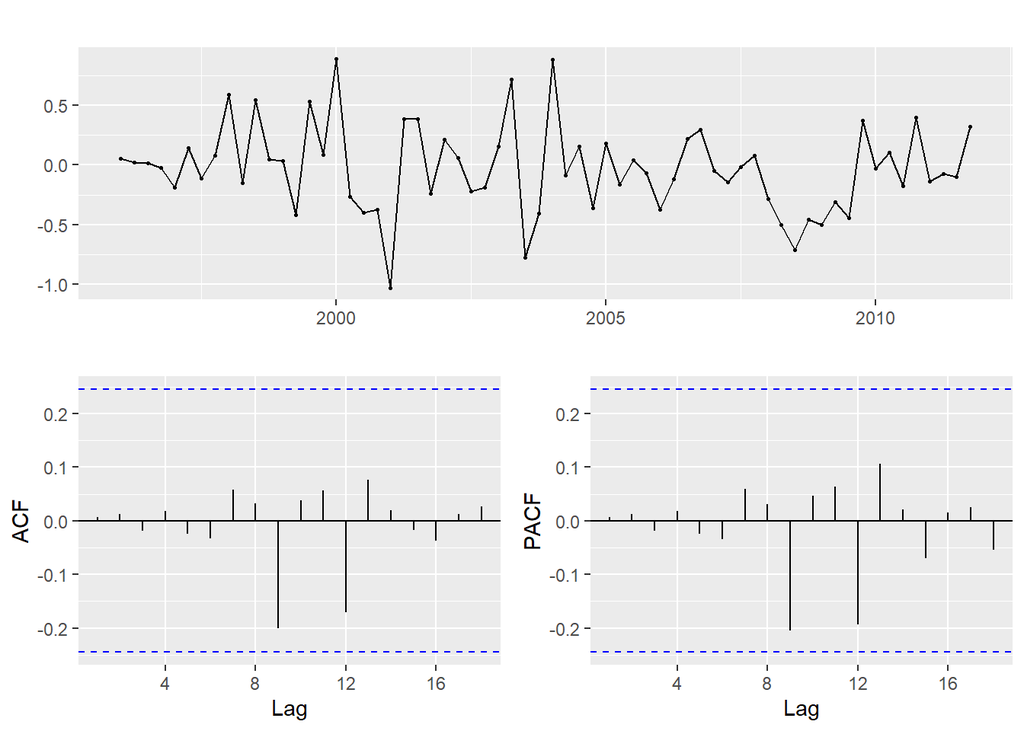

All peaks in the ACF and PACF plots are within significance, so the residuals appear to be white noise, which is a good result.

## Check residuals

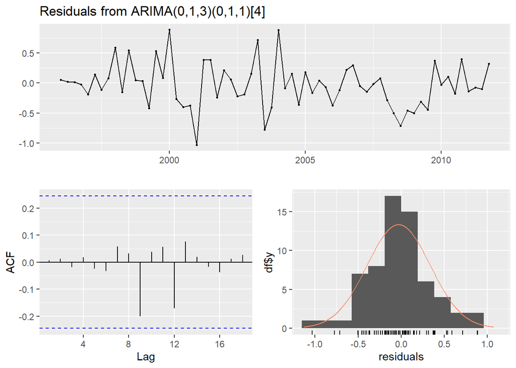

```
##
##  Ljung-Box test
##
## data:  Residuals from ARIMA(0,1,3)(0,1,1)[4]
## Q* = 0.51128, df = 4, p-value = 0.9724
##
## Model df: 4.   Total lags used: 8
```

The Ljung-Box test shows that the residuals are not autocorrelated and the distribution graph makes us think of a normal distribution of the residuals. We can therefore conclude that the residuals are random.

# Question 2

## Load dataset and display April 1st, 2022 COVID data

```
##              [,1]
## 2022-04-01 979881
```

## Plot a data

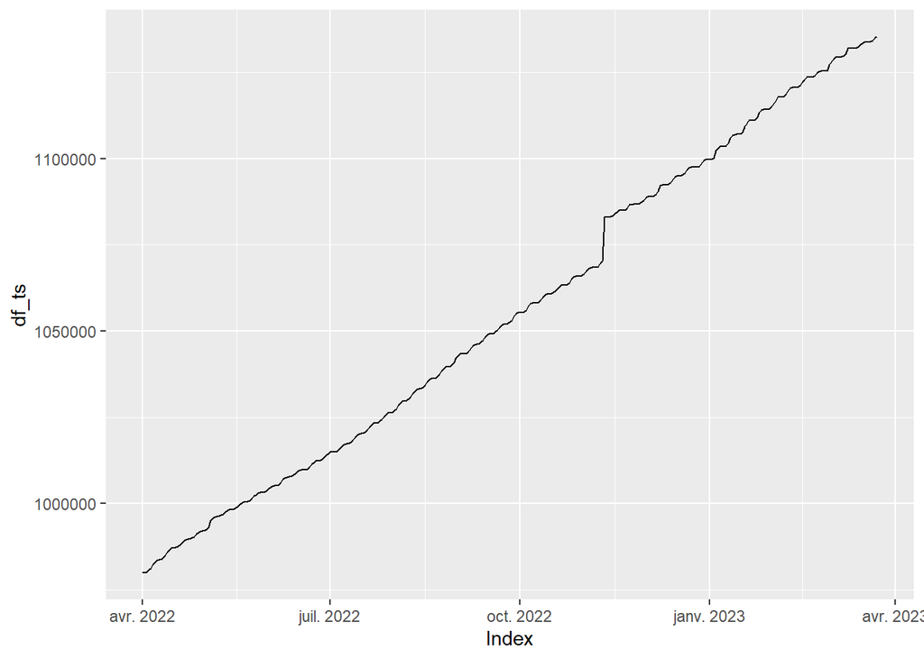

The data are non-stationary, with non-constant variance and mean, with a rising trend.

## Stationarity check

```
##
##  Augmented Dickey-Fuller Test
##
## data:  df_ts
## Dickey-Fuller = -2.4475, Lag order = 7, p-value = 0.388
## alternative hypothesis: stationary
```

With an alpha of 0.05 and p-value of 0.388, we fail to reject the null ans stat that the series is not stationary.

## Forecasting

```
## Series: df_ts
## ARIMA(0,1,0) with drift
##
## Coefficients:
##          drift
##       436.6910
## s.e.   39.5074
##
## sigma^2 = 559925:  log likelihood = -2859.71
## AIC=5723.42   AICc=5723.45   BIC=5731.17
##
## Training set error measures:
##                   ME     RMSE      MAE          MPE      MAPE     MASE     ACF1
## Training set 2.74354 746.1825 323.9385 0.0001863568 0.0304569 0.741316 0.071114
```

## Plot ACF and PACF of residuals

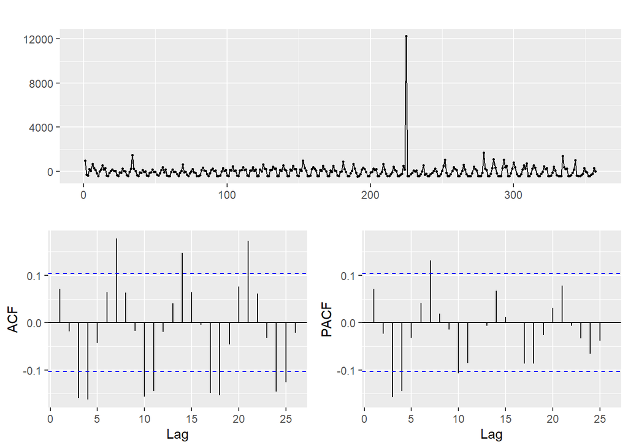

## Check residuals

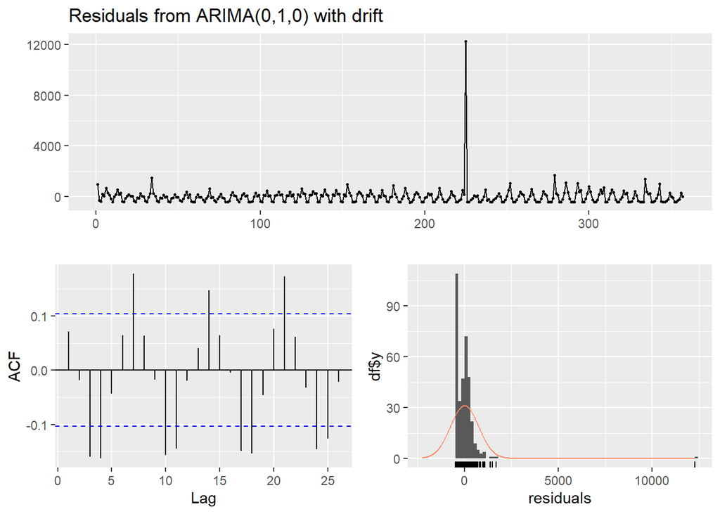

```
##
##  Ljung-Box test
##
## data:  Residuals from ARIMA(0,1,0) with drift
## Q* = 45.346, df = 10, p-value = 1.884e-06
##
## Model df: 0.   Total lags used: 10
```

The Ljung-Box test shows that the residues are autocorrelated.

## Repeat previous step for only 2023 COVID data

### Plot a data

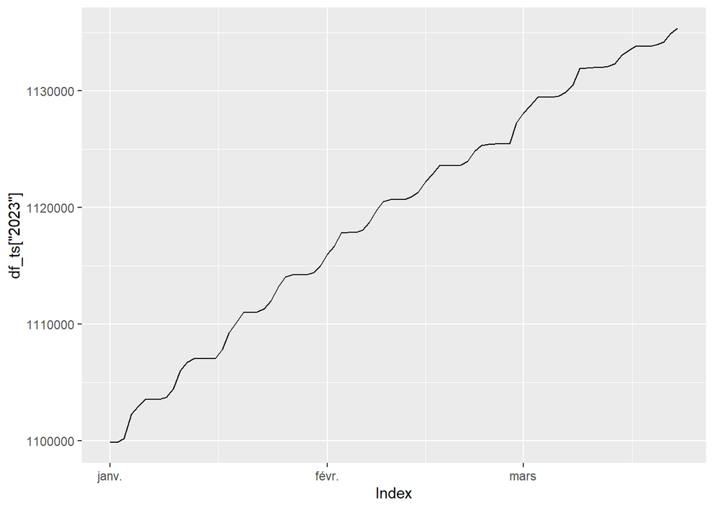

The data are non-stationary, with non-constant variance and mean, with a rising trend.

### Stationarity check

```
##
##  Augmented Dickey-Fuller Test
##
## data:  df_ts["2023"]
## Dickey-Fuller = -0.4558, Lag order = 4, p-value = 0.9816
## alternative hypothesis: stationary
```

With an alpha of 0.05 and p-value of 0.9816, we fail to reject the null ans stat that the series is not stationary.

### Forecasting

```
## Series: df_ts["2023"]
## ARIMA(0,1,1) with drift
##
## Coefficients:
##          ma1     drift
##       0.3620  436.9327
## s.e.  0.0954   66.2182
##
## sigma^2 = 212913:  log likelihood = -607.85
## AIC=1221.7   AICc=1222.01   BIC=1228.89
##
## Training set error measures:
##                    ME     RMSE      MAE         MPE       MAPE      MASE
## Training set 14.13465 452.9056 342.2886 0.001326475 0.03062918 0.7808206
##                      ACF1
## Training set -0.006837245
```

### Plot ACF and PACF of residuals

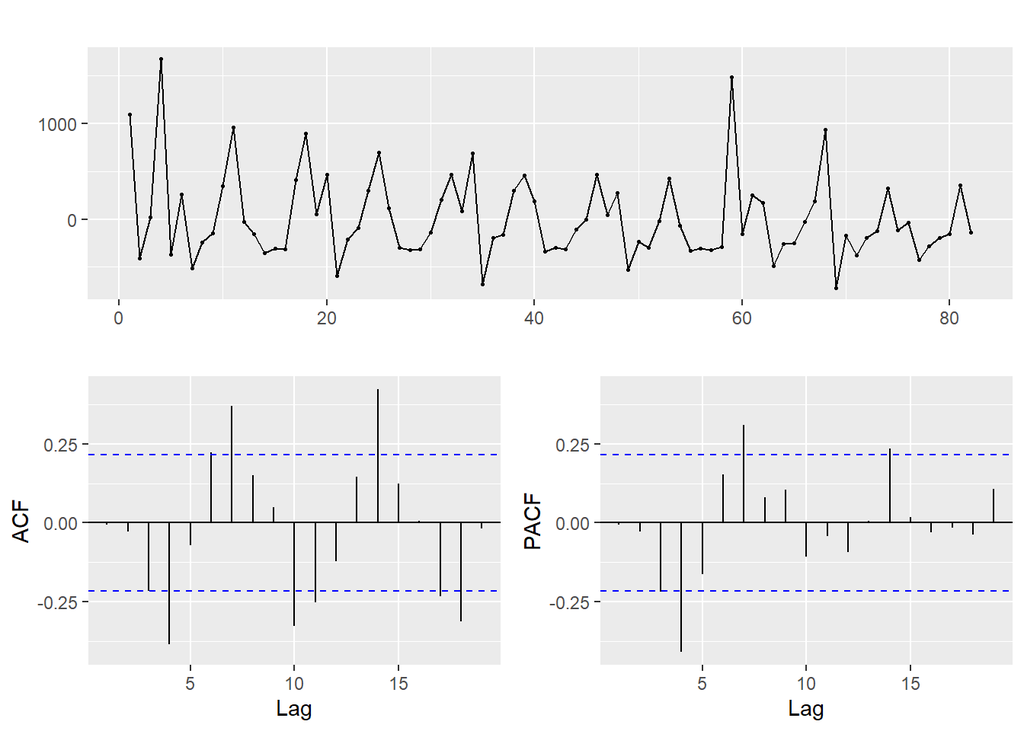

## Check residuals

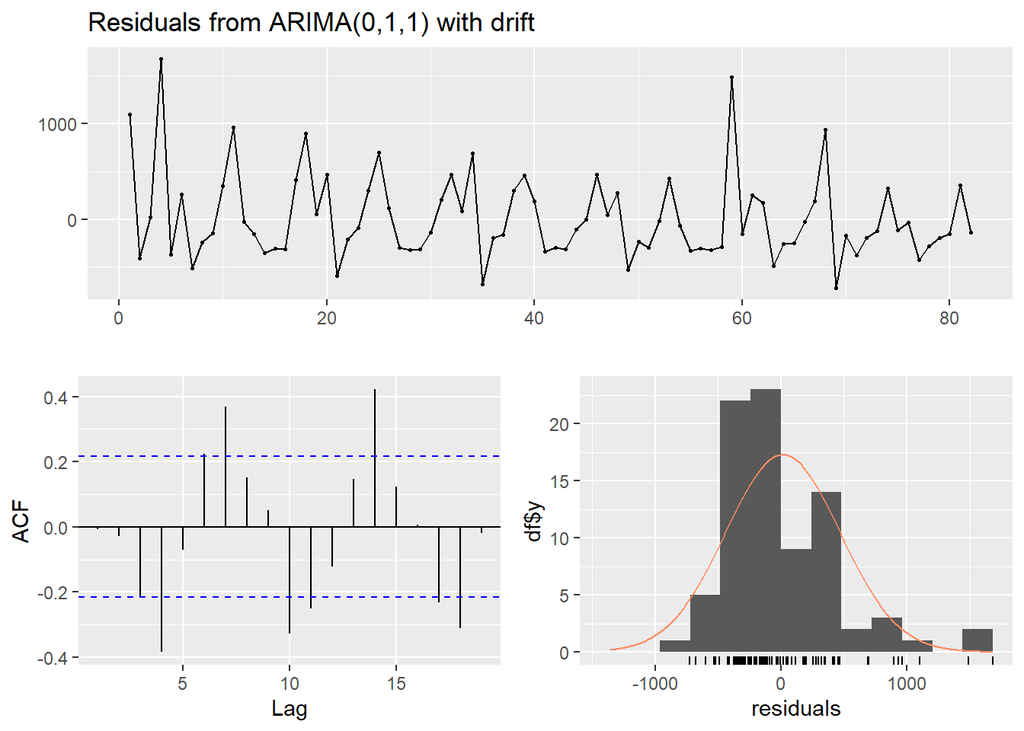

```
##
##  Ljung-Box test
##
## data:  Residuals from ARIMA(0,1,1) with drift
## Q* = 47.364, df = 9, p-value = 3.357e-07
##
## Model df: 1.   Total lags used: 10
```